# Chapter 11 Trade Policy in Developing Countries

# Preview

- Import-substituting industrialization
- Trade liberalization since 1985
- Trade and growth: takeoff in Asia

# Import-Substituting Industrialization

# Introduction

- Which countries are “developing countries”?
- The term “developing countries” does not have a precise definition, but it is a name given to many low- and middle-income countries.

# Gross Domestic Product Per Capita, 2009 (dollars)

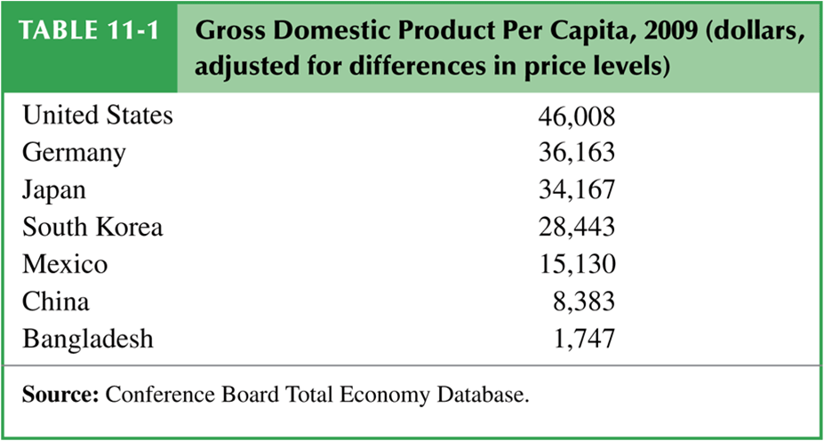

# Import-Substituting Industrialization

- Import-substituting industrialization was a trade policy adopted by many low- and middle-income countries before the 1980s.
- The policy aimed to encourage domestic industries by limiting competing imports.

# Effective Protection of Manufacturing in Some Developing Countries (percent)

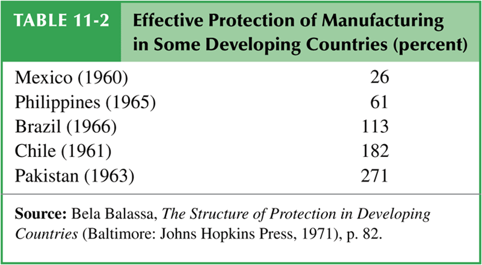

# Import-Substituting Industrialization

- The principal justification of this policy was/is the *infant industry argument*:
  - Countries may have a potential comparative advantage in some industries, but these industries cannot initially compete with well-established industries in other countries.
  - To allow these industries to establish themselves, governments should temporarily support them until they have grown strong enough to compete internationally.

# Results of Favoring Manufacturing: Problems of Import-Substituting Industrialization

# Problems with the Infant Industry Argument

1. It may be wasteful to support industries now that will have a comparative advantage in the future.
2. With protection, infant industries may never “grow up” or become competitive.
3. There is no justification for government intervention unless there is a market failure that prevents the private sector from investing in the infant industry.

# Infant Industries and Market Failures

- Two arguments for how market failures prevent infant industries from becoming competitive:
  1. Imperfect financial asset markets
     - Because of poorly working financial laws and markets (and more generally, a lack of property rights), firms cannot or do not save and borrow to invest sufficiently in their production processes.
     - If creating better functioning markets and enforcing laws is not feasible, then high tariffs would be a second-best policy to increase profits in new industries, leading to more rapid growth.

# Infant Industries and Market Failures

2. The problem of appropriability
   - Firms may not be able to privately appropriate the benefits of their investment in new industries because those benefits are public goods.
   - The knowledge created when starting an industry may not be appropriable (may be a public good) because of a lack of property rights.
   - If establishing a system of property rights is not feasible, then high tariffs would be a second-best policy to encourage growth in new industries.

# Import-Substituting Industrialization

- Import-substituting industrialization in Latin American countries worked to encourage manufacturing industries in the 1950s and 1960s.
- But economic development, not encouraging manufacturing, was the ultimate goal of the policy.
- Did import-substituting industrialization promote economic development?
  - No, countries adopting these policies grew more slowly than others.

# Import-Substituting Industrialization

- It appeared that the infant industry argument was not as valid as some had initially believed.
- New industries did not become competitive despite or because of trade restrictions.
- Import-substitution industrialization involved costs and promoted wasteful use of resources:
  - It involved complex, time-consuming regulations.
  - It set high tariff rates for consumers, including firms that needed to buy imported inputs for their products.
  - It promoted inefficiently small industries.

# Trade Liberalization Since 1985

# Trade Liberalization

- Some low- and middle-income countries that had relatively free trade had higher average economic growth than those that followed import substitution.
- By the mid-1980s, many governments had lost faith in import substitution and began to liberalize trade.
  - Dramatic fall in tariff rates in India and Brazil, and less drastic reductions in many other developing countries.

# Trade Liberalization

# Tariff Rates in Developing Countries

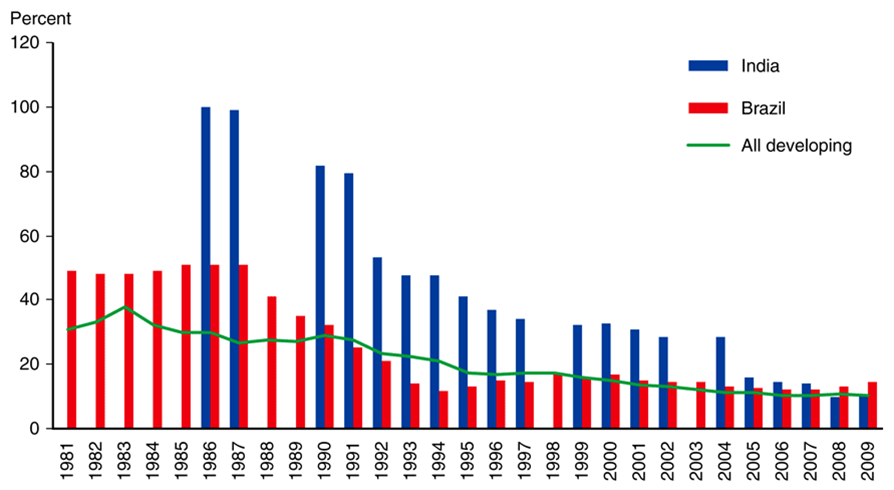

# The Growth of Developing-Country Trade

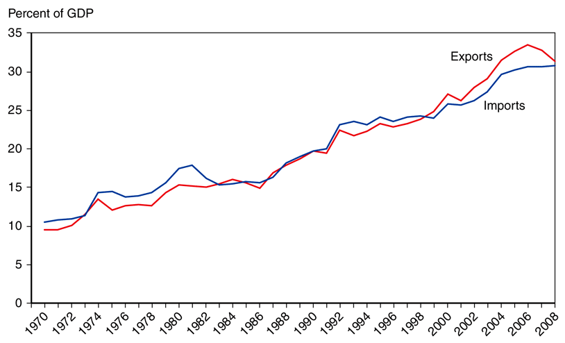

# Trade Liberalization

- Has trade liberalization promoted development? The evidence is mixed.
  - Growth rates in Brazil and other Latin American countries have been slower since trade liberalization than they were during import-substituting industrialization.
    - But unstable macroeconomic policies and financial crises contributed to slower growth since the 1980s.

# Trade Liberalization

- Other countries like India have grown rapidly since liberalizing trade in the 1980s, but it is unclear to what degree liberalized trade contributed to growth.
- Some economists also argue that trade liberalization has contributed to income inequality, as the Heckscher-Ohlin model predicts.

# Trade and Growth: Takeoff in Asia

# Trade and Growth: Takeoff in Asia

- Instead of import substitution, several countries in East Asia adopted trade policies that promoted exports in targeted industries.
  - Japan, Hong Kong, Taiwan, South Korea, Singapore, Malaysia, Thailand, Indonesia, and China have experienced rapid growth in various export sectors and rapid economic growth in general.

# Trade and Growth: Takeoff in Asia

- These high-performance Asian economies generated a high volume of exports and imports relative to total production.
- Their policy reforms were followed by a large increase in openness, as measured by their share of exports in GDP.
- So it is possible to develop through export-oriented growth.
- However, Latin American nations such as Mexico and Brazil, which also sharply liberalized trade and shifted toward exports, did not see comparable economic takeoffs.
- These Latin American results suggest that other factors must have played a crucial role in the Asian miracle.

# The Asian Takeoff

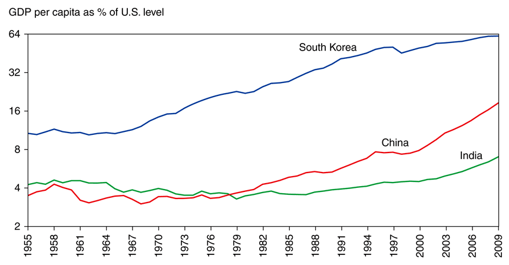

# Asia’s Surging Trade

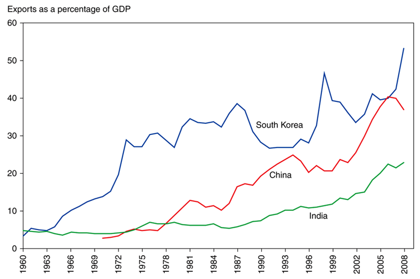

# Trade and Growth: Takeoff in Asia

- It’s unclear if the high volume of exports and imports caused rapid economic growth or was merely correlated with rapid economic growth.
  - High saving and investment rates could have led to both rapid economic growth in general and rapid economic growth in export sectors.
  - Rapid growth in education led to high literacy and numeracy rates important for a productive labor force.
  - These nations also undertook other economic reforms.

# Summary

# Summary

1. Import-substituting industrialization aimed to promote economic growth by restricting imports that competed with domestic products in low- and middle-income countries.
2. The infant industry argument says that new industries need temporary trade protection due to market failures:
   - imperfect asset markets that restrict saving, borrowing, and investment in production processes
   - problems of appropriating gains from private investment in production processes

# Summary

3. Import-substituting industrialization was tried in the 1950s and 1960s but by the mid-1980s it was abandoned for trade liberalization.
4. The effect of liberalized trade on national welfare is still being debated.
   - Trade helped growth in some sectors, but saying that trade *caused* higher overall economic growth has attracted some skepticism.
   - Some argue that trade has caused increased income inequality.

# Summary

5. Several East Asian economies adopted export- oriented instead of import-substituting industrialization.
   - High export and import volumes and relatively low trade restrictions were characteristics of this policy.
   - It’s unclear to what degree this policy contributed to overall economic growth, especially since other countries have not had similar successes.